# Homework Assignment #8

Waleed Khalid

2022-12-13

## Introduction

The dataset that I will explore in this assignment is from the Year 2021. The numbers of admitted students are presented for *Study programme group*, *Level of study*, and *Mother tongue*.

Here I will download the dataset to be explored following R code:

```
## # A tibble: 6 × 6
##   Level.of.study   Study.programme.group         Eston…¹ Russian Other…² Mothe…³
##   <chr>            <chr>                           <int>   <int>   <int>   <int>
## 1 Bachelor's study Journalism and information         82       3       0       0
## 2 Bachelor's study Architecture and construction      31       7       0       0
## 3 Bachelor's study Biological and environmental…     215      45       1       0
## 4 Bachelor's study Physical sciences                 173      53      20      11
## 5 Bachelor's study Humanities                        124      24       5       9
## 6 Bachelor's study Information and Communicatio…     571     165      14      23
## # … with abbreviated variable names ¹Estonian, ²Other.mother.tongue,
## #   ³Mother.tongue.unknown
```

## EDA

1.What are the data types of the variables?

```
## tibble [108 × 6] (S3: tbl_df/tbl/data.frame)
##  $ Level.of.study       : chr [1:108] "Bachelor's study" "Bachelor's study" "Bachelor's study" "Bachelor's study" ...
##  $ Study.programme.group: chr [1:108] "Journalism and information" "Architecture and construction" "Biological and environmental sciences" "Physical sciences" ...
##  $ Estonian             : int [1:108] 82 31 215 173 124 571 25 266 206 67 ...
##  $ Russian              : int [1:108] 3 7 45 53 24 165 0 84 40 22 ...
##  $ Other.mother.tongue  : int [1:108] 0 0 1 20 5 14 0 7 8 1 ...
##  $ Mother.tongue.unknown: int [1:108] 0 0 0 11 9 23 0 0 23 0 ...
```

2.What is the mean for each variable?

```
##  Level.of.study     Study.programme.group    Estonian         Russian
##  Length:108         Length:108            Min.   :  0.00   Min.   :  0.00
##  Class :character   Class :character      1st Qu.:  0.00   1st Qu.:  0.00
##  Mode  :character   Mode  :character      Median : 12.50   Median :  1.00
##                                           Mean   : 66.64   Mean   : 12.57
##                                           3rd Qu.: 74.25   3rd Qu.: 13.00
##                                           Max.   :571.00   Max.   :165.00
##  Other.mother.tongue Mother.tongue.unknown
##  Min.   :  0.000     Min.   : 0.000
##  1st Qu.:  0.000     1st Qu.: 0.000
##  Median :  0.000     Median : 0.000
##  Mean   :  7.231     Mean   : 6.583
##  3rd Qu.:  7.250     3rd Qu.: 4.000
##  Max.   :103.000     Max.   :88.000
```

3.Are there any Null / NA values?

```
## [1] 0
```

## Analysis

Prepare the data set that includes only variables of your interest in a suitable format for analysis (use `dlyr` package and `tidyr` when necessary).

New Data Set

```
## # A tibble: 6 × 3
## # Groups:   Level.of.study [2]
##   Level.of.study   mother.tongue         sum.of.students
##   <chr>            <chr>                           <int>
## 1 Bachelor's study Estonian                         3705
## 2 Bachelor's study Mother.tongue.unknown             263
## 3 Bachelor's study Other.mother.tongue               115
## 4 Bachelor's study Russian                           806
## 5 Doctoral study   Estonian                          169
## 6 Doctoral study   Mother.tongue.unknown              34
```

## Research

3. Based on the dataset, formulate your *Research Question(s)*. Think of questions that you can answer with the help of either *chi-square* statistical test or some type of *t-test*.

Question: Is there a relation between level of study and the mother tounge of students I will be using Chi- Test

```
##                                       mother.tongue
## Level.of.study                         Estonian Mother.tongue.unknown
##   Bachelor's study                         3705                   263
##   Doctoral study                            169                    34
##   Integrated Bachelor's/Master's study      519                    11
##   Master's study                           2804                   403
##                                       mother.tongue
## Level.of.study                         Other.mother.tongue Russian
##   Bachelor's study                                     115     806
##   Doctoral study                                        90      23
##   Integrated Bachelor's/Master's study                  50      91
##   Master's study                                       526     438
```

Visualizing the results

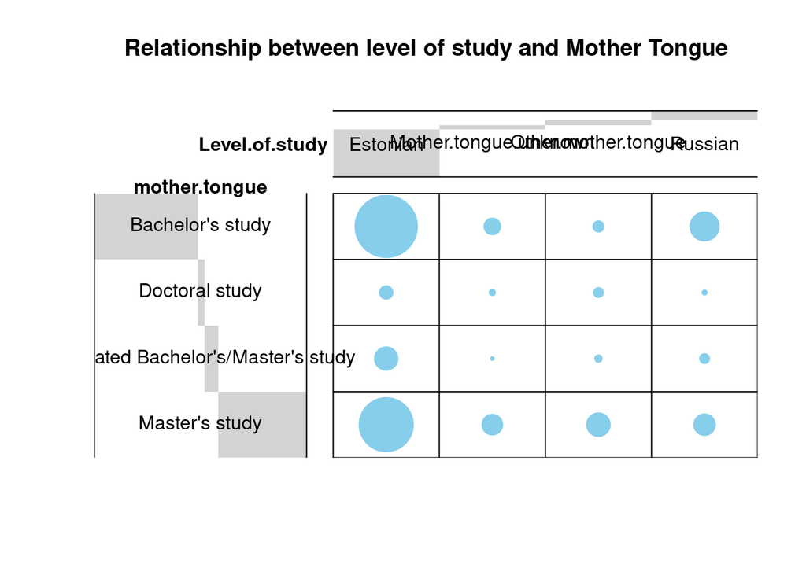

Fromt the graph we can see that estonian level is in majority

## Hypothesis testing

### Stating the null hypothesis and the alternative hypothesis.

the level of study and mother tongue are independent the alternative is they are dependent

## checking the assumption

First the sampple was randomly selected and also there are minimun of 5 observation expectred in each group

```
##
##  Pearson's Chi-squared test
##
## data:  cdftable
## X-squared = 687.89, df = 9, p-value < 2.2e-16
```

```
##                                       mother.tongue
## Level.of.study                          Estonian Mother.tongue.unknown
##   Bachelor's study                     3502.1532             345.98179
##   Doctoral study                        226.3613              22.36250
##   Integrated Bachelor's/Master's study  480.6596              47.48492
##   Master's study                       2987.8259             295.17080
##                                       mother.tongue
## Level.of.study                         Other.mother.tongue   Russian
##   Bachelor's study                               380.04469 660.82034
##   Doctoral study                                  24.56415  42.71205
##   Integrated Bachelor's/Master's study            52.15995  90.69553
##   Master's study                                 324.23121 563.77207
```

The chi square value is 687